# Loan Prediction

## Correlation Analysis

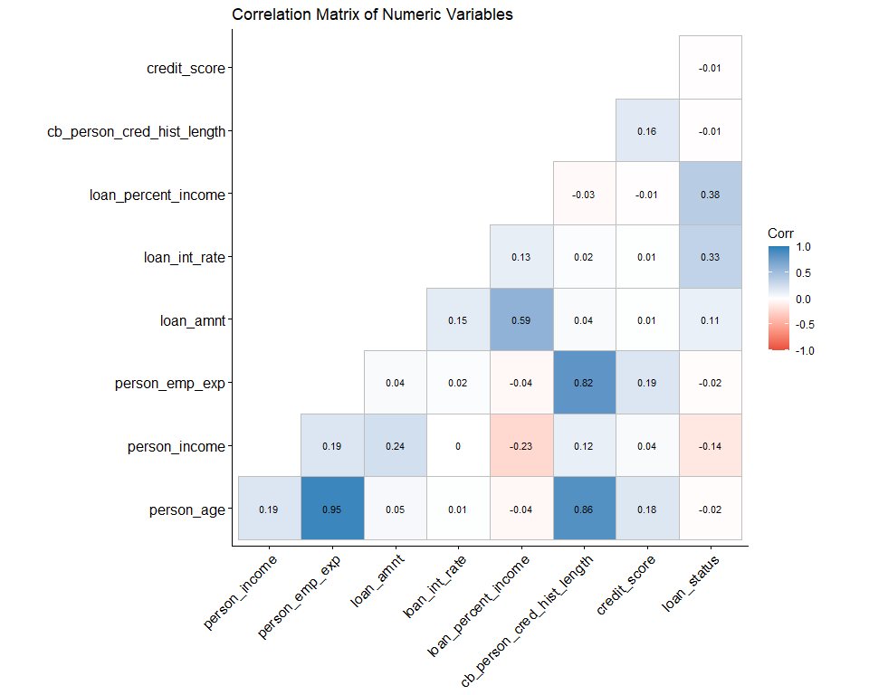

```r
# Select numeric variables for correlation
numeric_df <- df %>% dplyr::select(where(is.numeric))

cor_matrix <- cor(numeric_df, use = "complete.obs")

ggcorrplot(cor_matrix,
           method = "square",
           type = "lower",
           lab = TRUE,
           lab_size = 3,
           colors = c("#e74c3c", "white", "#2980b9"),
           title = "Correlation Matrix of Numeric Variables",
           ggtheme = theme_classic())
```

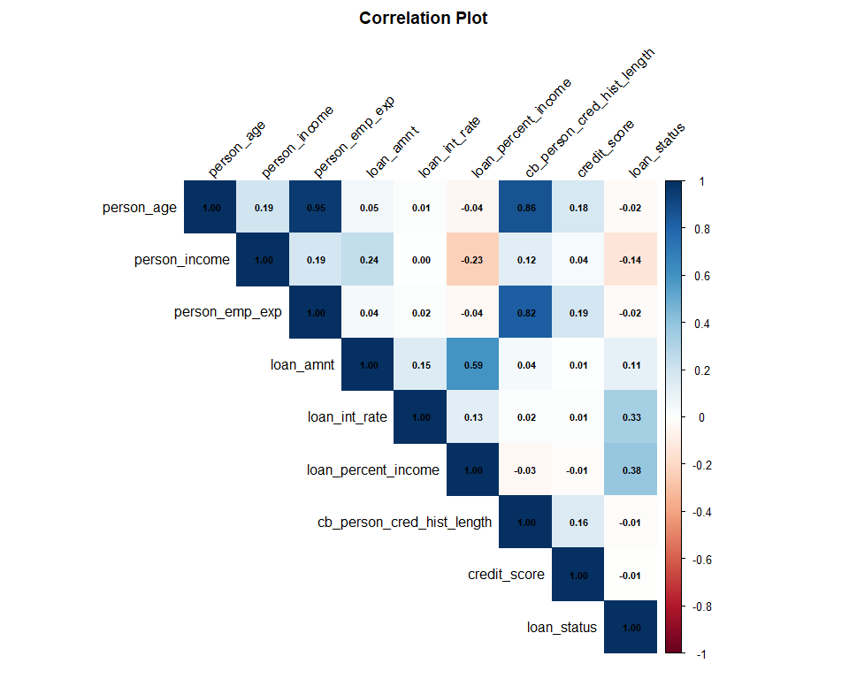

```r
corrplot(cor_matrix, method = "color", type = "upper",
         addCoef.col = "black", number.cex = 0.7,
         tl.col = "black", tl.srt = 45,
         title = "Correlation Plot", mar = c(0,0,2,0))
```

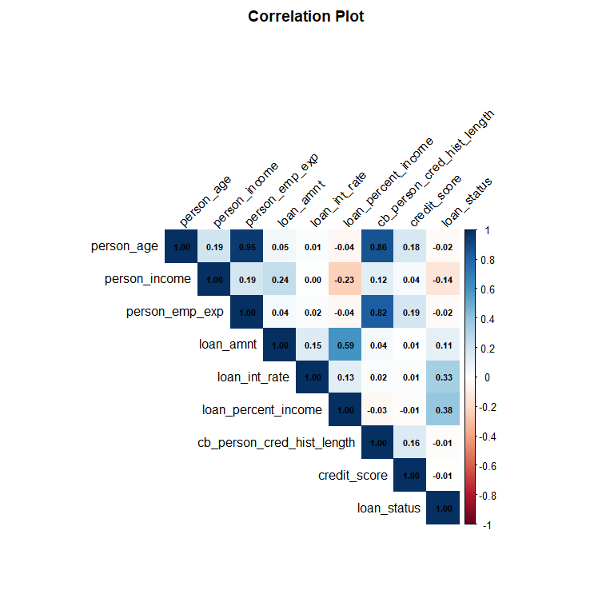

```r
corrplot(cor_matrix, method = "color", type = "upper",
         addCoef.col = "black", number.cex = 0.7,
         tl.col = "black", tl.srt = 45,
         title = "Correlation Plot", mar = c(0,0,2,0))
```

# Data Preprocessing

## Outlier Treatment

From our EDA, we identified biologically and logically implausible values that need to be removed or capped.

```r
cat("Before outlier treatment:", nrow(df), "rows\n\n")
```

```
Before outlier treatment: 45000 rows
```

```r
# Remove biologically implausible ages (> 80)
cat("Ages > 80:", sum(df$person_age > 80), "\n")
```

```
Ages > 80: 9
```

```r
df <- df %>% filter(person_age <= 80)

# Remove implausible employment experience (> 60 years)
cat("Employment experience > 60:", sum(df$person_emp_exp > 60), "\n")
```

```
Employment experience > 60: 1
```

```r
df <- df %>% filter(person_emp_exp <= 60)

# Cap extreme income values (> 99.5th percentile)
income_cap <- quantile(df$person_income, 0.995)
cat("Income cap (99.5th percentile):", income_cap, "\n")
```

```
Income cap (99.5th percentile): 360727.5
```

```r
cat("Records above cap:", sum(df$person_income > income_cap), "\n")
```

```
Records above cap: 225
```

```r
df <- df %>% filter(person_income <= income_cap)

cat("\nAfter outlier treatment:", nrow(df), "rows\n")
```

```
After outlier treatment: 44765 rows
```

## Encode Categorical Variables

For modeling, we convert categorical variables to factors (R handles factor encoding internally for  
regression and tree-based models).

```r
df <- df %>%
  mutate(
    person_gender    = as.factor(person_gender),
    person_education = factor(person_education,
                              levels = c("High School", "Associate", "Bachelor",
                                         "Master", "Doctorate"),
                              ordered = TRUE),
    person_home_ownership = as.factor(person_home_ownership),
    loan_intent      = as.factor(loan_intent),
    previous_loan_defaults_on_file = as.factor(previous_loan_defaults_on_file),
    loan_status      = as.factor(loan_status)
  )

str(df)
```

```
tibble [44,765 × 14] (S3: tbl_df/tbl/data.frame)
 $ person_age                    : num [1:44765] 22 21 25 23 24 21 26 24 24 21 ...
 $ person_gender                 : Factor w/ 2 levels "female","male": 1 1 1 1 2 1 1 1 1 1 ...
 $ person_education              : Ord.factor w/ 5 levels "High School"<..: 4 1 1 3 4 1 3 1 2 1 ...
 $ person_income                 : num [1:44765] 71948 12282 12438 79753 66135 ...
 $ person_emp_exp                : num [1:44765] 0 0 3 0 1 0 1 5 3 0 ...
 $ person_home_ownership         : Factor w/ 4 levels "MORTGAGE","OTHER",..: 4 3 1 4 4 3 4 4 4 3 ...
 $ loan_amnt                     : num [1:44765] 35000 1000 5500 35000 35000 2500 35000 35000 35000 1600 ...
 $ loan_intent                   : Factor w/ 6 levels "DEBTCONSOLIDATION",..: 5 2 4 4 4 6 2 4 5 6 ...
 $ loan_int_rate                 : num [1:44765] 16 11.1 12.9 15.2 14.3 ...
 $ loan_percent_income           : num [1:44765] 0.49 0.08 0.44 0.44 0.53 0.19 0.37 0.37 0.35 0.13 ...
 $ cb_person_cred_hist_length    : num [1:44765] 3 2 3 2 4 2 3 4 2 3 ...
 $ credit_score                  : num [1:44765] 561 504 635 675 586 532 701 585 544 640 ...
 $ previous_loan_defaults_on_file: Factor w/ 2 levels "No","Yes": 1 2 1 1 1 1 1 1 1 1 ...
 $ loan_status                   : Factor w/ 2 levels "0","1": 2 1 2 2 2 2 2 2 2 2 ...
```

# Feature Engineering

In this caser feature engineering creates new informative variables that may capture relationships the raw data does not explicitly represent.

```r
# Create features first
df$loan_credit_ratio    <- df$loan_amnt / df$credit_score
df$age_exp_ratio        <- ifelse(df$person_age > 0, df$person_emp_exp / df$person_age, 0)
df$income_per_exp       <- ifelse(df$person_emp_exp > 0, df$person_income / df$person_emp_exp, df$person_income)
df$credit_hist_per_age  <- df$cb_person_cred_hist_length / df$person_age
df$high_risk            <- as.factor(ifelse(df$loan_percent_income > 0.3 & df$credit_score < 600, 1, 0))
df$age_group            <- cut(df$person_age, breaks = c(19, 25, 35, 50, 80),
                               labels = c("Young Adult", "Adult", "Middle Age", "Senior"))
df$income_bracket       <- cut(df$person_income,
                               breaks = quantile(df$person_income, probs = c(0, 0.25, 0.5, 0.75, 1)),
                               labels = c("Low", "Lower-Mid", "Upper-Mid", "High"),
                               include.lowest = TRUE)

p1 <- ggplot(df, aes(x = loan_status, y = loan_credit_ratio, fill = loan_status)) +
  geom_boxplot(alpha = 0.7) +
  scale_fill_manual(values = c("#e74c3c", "#27ae60")) +
  labs(title = "Loan-to-Credit Ratio by Status", y = "Loan/Credit Ratio") +
  theme(legend.position = "none")
```

```r
p2 <- ggplot(df, aes(x = high_risk, fill = loan_status)) +
  geom_bar(position = "fill", alpha = 0.8) +
  scale_fill_manual(values = c("#e74c3c", "#27ae60"),
                    labels = c("Default", "Repaid")) +
  labs(title = "Default Rate: High Risk vs Not", y = "Proportion") +
  theme(legend.position = "bottom")
```

```r
p3 <- ggplot(df, aes(x = age_group, fill = loan_status)) +
  geom_bar(position = "fill", alpha = 0.8) +
  scale_fill_manual(values = c("#e74c3c", "#27ae60"),
                    labels = c("Default", "Repaid")) +
  labs(title = "Default Rate by Age Group", y = "Proportion") +
  theme(legend.position = "bottom", axis.text.x = element_text(angle = 30, hjust = 1))
```

```r
p4 <- ggplot(df, aes(x = income_bracket, fill = loan_status)) +
  geom_bar(position = "fill", alpha = 0.8) +
  scale_fill_manual(values = c("#e74c3c", "#27ae60"),
                    labels = c("Default", "Repaid")) +
  labs(title = "Default Rate by Income Bracket", y = "Proportion") +
  theme(legend.position = "bottom")
```

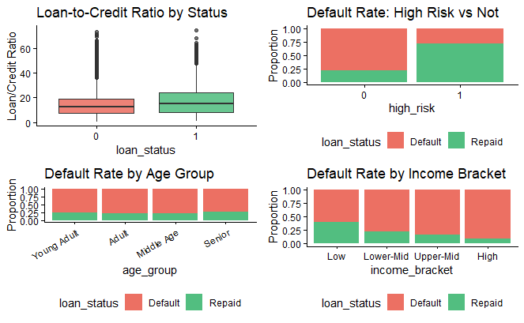

```r
grid.arrange(p1, p2, p3, p4, ncol = 2)
```

# Part A: Regression Predicting Income

## Objective

We trainng three regression models to predict `person_income` using personal demographic variables: `person_age`, `person_gender`, `person_education`, `person_emp_exp`, `person_home_ownership`, and engineered features.

## Prepare Regression Data

```r
# Select personal information variables for income prediction
reg_df <- df %>%
  select(person_income, person_age, person_gender, person_education,
         person_emp_exp, person_home_ownership,
         age_exp_ratio, credit_hist_per_age) %>%
  drop_na()
```

```r
# Convert ordered factor to unordered for regression compatibility
reg_df$person_education <- factor(reg_df$person_education, ordered = FALSE)

cat("Regression dataset:", nrow(reg_df), "rows x", ncol(reg_df), "columns\n")
```

```
Regression dataset: 44765 rows x 8 columns
```

```r
summary(reg_df$person_income)
```

```
   Min. 1st Qu.  Median    Mean 3rd Qu.    Max.
   8000   47063   66968   77224   94805  360724
```

## Check Distribution of Target Income

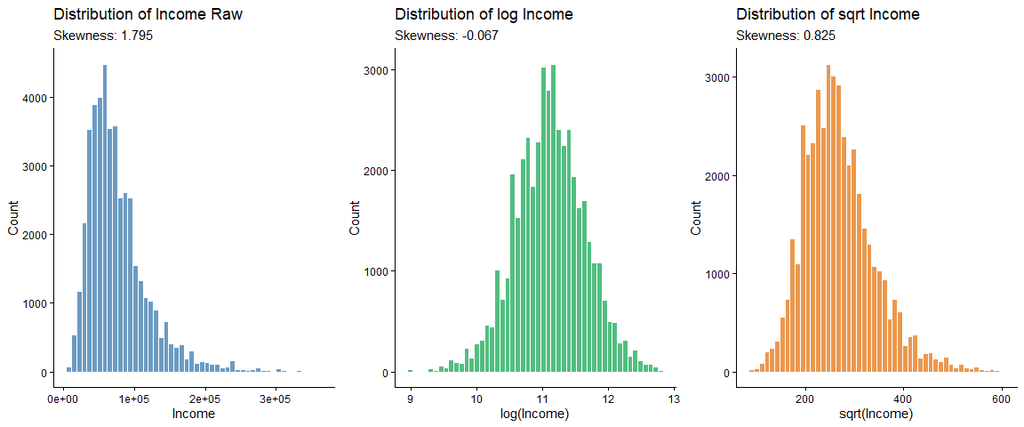

```r
p1 <- ggplot(reg_df, aes(x = person_income)) +
  geom_histogram(bins = 50, fill = "steelblue", color = "white", alpha = 0.8) +
  labs(title = "Distribution of Income Raw",
       subtitle = paste("Skewness:", round(skewness(reg_df$person_income), 3)),
       x = "Income", y = "Count")

p2 <- ggplot(reg_df, aes(x = log(person_income))) +
  geom_histogram(bins = 50, fill = "#27ae60", color = "white", alpha = 0.8) +
  labs(title = "Distribution of log Income",
       subtitle = paste("Skewness:", round(skewness(log(reg_df$person_income)), 3)),
       x = "log(Income)", y = "Count")

p3 <- ggplot(reg_df, aes(x = sqrt(person_income))) +
  geom_histogram(bins = 50, fill = "#e67e22", color = "white", alpha = 0.8) +
  labs(title = "Distribution of sqrt Income ",
       subtitle = paste("Skewness:", round(skewness(sqrt(reg_df$person_income)), 3)),
       x = "sqrt(Income)", y = "Count")

grid.arrange(p1, p2, p3, ncol = 3)
```

**Decision:** The log transformation substantially reduces skewness, making the distribution closer to normal. We will use `log(person_income)` as the response variable for linear regression.

```r
reg_df <- reg_df %>% mutate(log_income = log(person_income))
```

## Train-Test Split

```r
set.seed(42)
train_index <- createDataPartition(reg_df$log_income, p = 0.8, list = FALSE)
train_reg <- reg_df[train_index, ]
test_reg  <- reg_df[-train_index, ]

cat("Training set:", nrow(train_reg), "rows\n")
```

```
Training set: 35813 rows
```

```r
cat("Test set:", nrow(test_reg), "rows\n")
```

```
Test set: 8952 rows
```

## Model 1: Linear Regression

```r
lm_full <- lm(log_income ~ person_age + person_gender + person_education +
                 person_emp_exp + person_home_ownership + age_exp_ratio +
                 credit_hist_per_age,
               data = train_reg)

summary(lm_full)
```

```
Call:
lm(formula = log_income ~ person_age + person_gender + person_education +
    person_emp_exp + person_home_ownership + age_exp_ratio +
    credit_hist_per_age, data = train_reg)

Residuals:
     Min       1Q   Median       3Q      Max
-2.13605 -0.32017  0.00155  0.32174  1.90153

Coefficients:
                             Estimate Std. Error t value Pr(>|t|)
(Intercept)                10.6381256  0.0387303 274.672  < 2e-16 ***
person_age                  0.0286197  0.0017060  16.775  < 2e-16 ***
person_gendermale           0.0100934  0.0052283   1.931 0.053549 .
person_educationAssociate  -0.0085669  0.0071375  -1.200 0.230045
person_educationBachelor   -0.0006393  0.0069707  -0.092 0.926925
person_educationMaster      0.0058151  0.0083396   0.697 0.485624
person_educationDoctorate  -0.0412953  0.0227216  -1.817 0.069158 .
person_emp_exp             -0.0493778  0.0027716 -17.815  < 2e-16 ***
person_home_ownershipOTHER -0.1795566  0.0514544  -3.490 0.000484 ***
person_home_ownershipOWN   -0.4414663  0.0109738 -40.229  < 2e-16 ***
person_home_ownershipRENT  -0.4031102  0.0054337 -74.187  < 2e-16 ***
age_exp_ratio               1.3177276  0.0735210  17.923  < 2e-16 ***
credit_hist_per_age        -0.1893435  0.0423819  -4.468 7.94e-06 ***
---
Signif. codes:  0 ‘***’ 0.001 ‘**’ 0.01 ‘*’ 0.05 ‘.’ 0.1 ‘ ’ 1

Residual standard error: 0.4919 on 35800 degrees of freedom
Multiple R-squared:  0.1609,    Adjusted R-squared:  0.1607
F-statistic: 572.2 on 12 and 35800 DF,  p-value: < 2.2e-16
```

### Stepwise Variable Selection

Stepwise selection uses AIC ) to iteratively add and remove predictors at each step.

```r
lm_step <- stepAIC(lm_full, direction = "both", trace = TRUE)
```

```
Start:  AIC=-50809.75
log_income ~ person_age + person_gender + person_education +
    person_emp_exp + person_home_ownership + age_exp_ratio +
    credit_hist_per_age

                        Df Sum of Sq     RSS    AIC
- person_education       4      1.56  8662.6 -50811
<none>                                8661.0 -50810
- person_gender          1      0.90  8661.9 -50808
- credit_hist_per_age    1      4.83  8665.9 -50792
- person_age             1     68.08  8729.1 -50531
- person_emp_exp         1     76.79  8737.8 -50496
- age_exp_ratio          1     77.72  8738.7 -50492
- person_home_ownership  3   1432.22 10093.2 -45335

Step:  AIC=-50811.29
log_income ~ person_age + person_gender + person_emp_exp + person_home_ownership +
    age_exp_ratio + credit_hist_per_age

                        Df Sum of Sq     RSS    AIC
<none>                                8662.6 -50811
+ person_education       4      1.56  8661.0 -50810
- person_gender          1      0.90  8663.5 -50810
- credit_hist_per_age    1      4.94  8667.5 -50793
- person_age             1     67.74  8730.3 -50534
- person_emp_exp         1     77.24  8739.8 -50495
- age_exp_ratio          1     78.27  8740.9 -50491
- person_home_ownership  3   1432.36 10094.9 -45337
```

```r
summary(lm_step)
```

```
Call:
lm(formula = log_income ~ person_age + person_gender + person_emp_exp +
    person_home_ownership + age_exp_ratio + credit_hist_per_age,
    data = train_reg)

Residuals:
     Min       1Q   Median       3Q      Max
-2.13489 -0.32048  0.00116  0.32234  1.90226

Coefficients:
                            Estimate Std. Error t value Pr(>|t|)
(Intercept)                10.639406   0.038603 275.607  < 2e-16 ***
person_age                  0.028511   0.001704  16.732  < 2e-16 ***
person_gendermale           0.010068   0.005228   1.926 0.054171 .
person_emp_exp             -0.049369   0.002763 -17.867  < 2e-16 ***
person_home_ownershipOTHER -0.180106   0.051454  -3.500 0.000465 ***
person_home_ownershipOWN   -0.441517   0.010973 -40.235  < 2e-16 ***
person_home_ownershipRENT  -0.403101   0.005434 -74.187  < 2e-16 ***
age_exp_ratio               1.317468   0.073249  17.986  < 2e-16 ***
credit_hist_per_age        -0.191452   0.042369  -4.519 6.24e-06 ***
---
Signif. codes:  0 ‘***’ 0.001 ‘**’ 0.01 ‘*’ 0.05 ‘.’ 0.1 ‘ ’ 1

Residual standard error: 0.4919 on 35804 degrees of freedom
Multiple R-squared:  0.1608,    Adjusted R-squared:  0.1606
F-statistic: 857.5 on 8 and 35804 DF,  p-value: < 2.2e-16
```

```r
cat("Full Model AIC:", AIC(lm_full), "\n")
```

```
Full Model AIC: 50825.14
```

```r
cat("Stepwise Model AIC:", AIC(lm_step), "\n")
```

```
Stepwise Model AIC: 50823.6
```

```r
cat("Full Model Adj R²:", summary(lm_full)$adj.r.squared, "\n")
```

```
Full Model Adj R²: 0.1606579
```

```r
cat("Stepwise Model Adj R²:", summary(lm_step)$adj.r.squared, "\n")
```

```
Stepwise Model Adj R²: 0.1606002
```

### Checking Linear Regression Assumptions

We systematically check all four key assumptions of ordinary least squares (OLS) regression

#### Assumption 1: Linearity (Residuals vs Fitted)

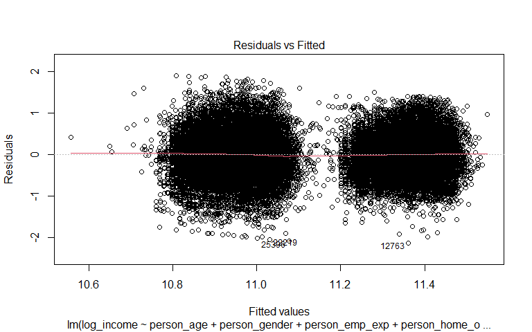

```r
plot(lm_step, which = 1)
```

**Interpretation:** If the red line is approximately horizontal and centered at zero, the linearity assumption holds. Systematic patterns (curves, funnels) indicate non-linearity.

#### Assumption 2: Normality of Residuals

```r
par(mfrow = c(1, 2))
# Q-Q Plot
plot(lm_step, which = 2)

# Histogram of residuals
hist(residuals(lm_step), breaks = 50, col = "steelblue", border = "white",
     main = "Histogram of Residuals", xlab = "Residuals", probability = TRUE)
```

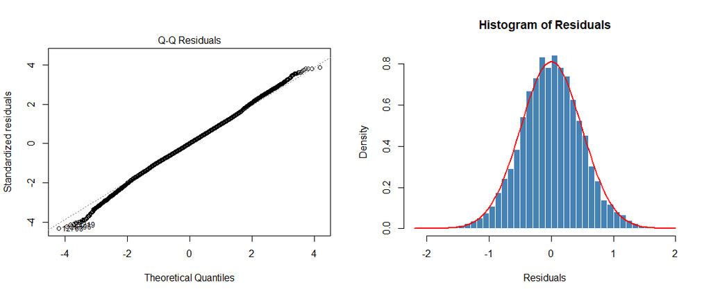

```r
curve(dnorm(x, mean = mean(residuals(lm_step)), sd = sd(residuals(lm_step))),
      add = TRUE, col = "red", lwd = 2)
par(mfrow = c(1, 1))
```

#### Assumption 3: Homoscedasticity Constant Variance

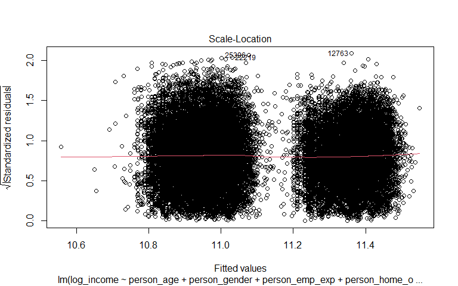

```r
plot(lm_step, which = 3)
```

**Interpretation:** The Scale-Location plot should show a roughly horizontal line with equally spread points. A funnel shape indicates heteroscedasticity.

#### Assumption 4: No Multicollinearity

```r
vif_values <- vif(lm_step)
print(vif_values)
```

```
                           GVIF Df GVIF^(1/(2*Df))
person_age            14.771889  1        3.843422
person_gender          1.000922  1        1.000461
person_emp_exp        39.052979  1        6.249238
person_home_ownership  1.004622  3        1.000769
age_exp_ratio         16.607120  1        4.075183
credit_hist_per_age    2.137388  1        1.461981
```

```r
cat("\nVariables with VIF > 5 (potential multicollinearity concern):\n")
```

```
Variables with VIF > 5 (potential multicollinearity concern):
```

```r
high_vif <- vif_values[apply(as.matrix(vif_values[, "GVIF^(1/(2*Df))"]), 1,
                             function(x) x > 2.5)]
if (length(high_vif) > 0) print(high_vif) else cat("None detected.\n")
```

```
[1] 14.771889 39.052979 16.607120  1.000000  1.000000  1.000000  3.843422  6.249238  4.075183
```

**Rule of thumb:** Generalized VIF^(1/(2*Df)) > 2.5 suggests multicollinearity.

#### Influence & Leverage (Cook’s Distance)

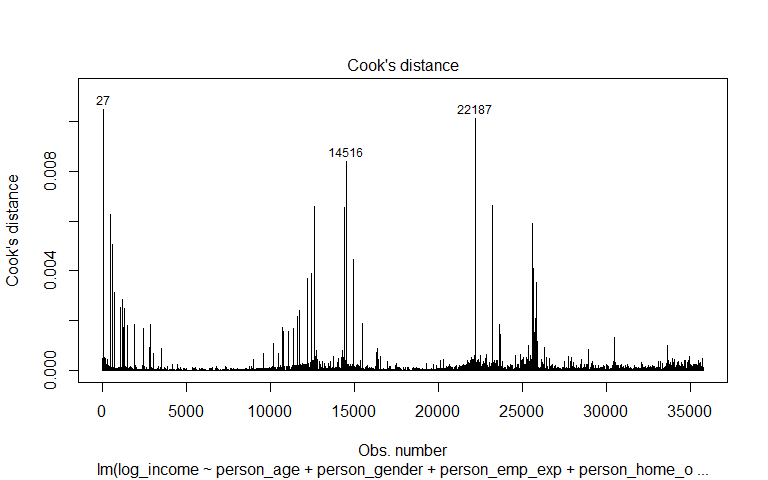

```r
plot(lm_step, which = 4)
```

```r
# Identify influential observations
cooks_d <- cooks.distance(lm_step)
influential <- which(cooks_d > 4 / nrow(train_reg))
cat("Number of influential observations (Cook's D > 4/n):", length(influential), "\n")
```

```
Number of influential observations (Cook's D > 4/n): 1656
```

### All Diagnostic Plots Together

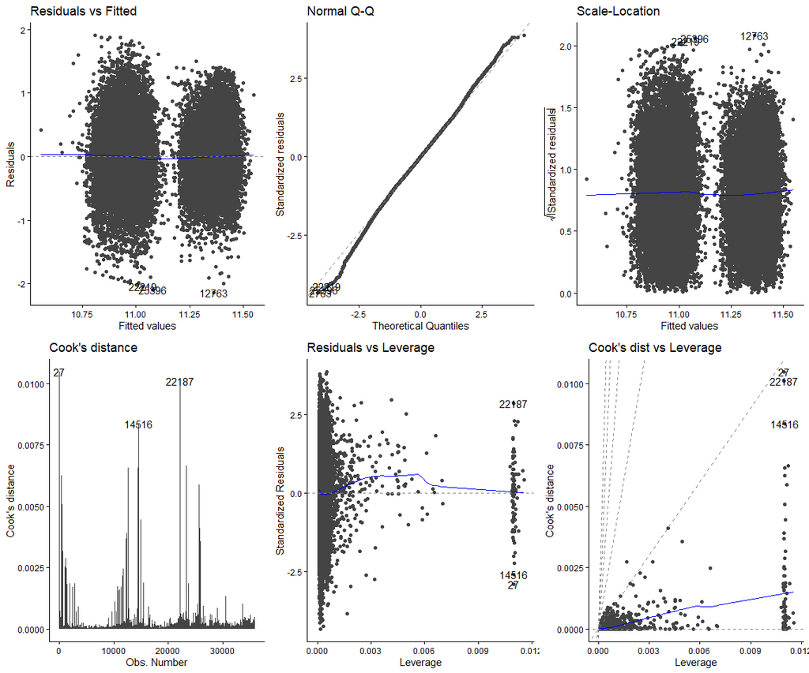

```r
autoplot(lm_step, which = 1:6, ncol = 3) + theme_classic()
```

### Attempting Additional Transformations

If assumptions are violated, we try alternative transformations.

```r
# Square root transformation
lm_sqrt <- lm(sqrt(person_income) ~ person_age + person_gender + person_education +
                person_emp_exp + person_home_ownership,
              data = train_reg)

cat("--- Log Transform Adj R²:", summary(lm_step)$adj.r.squared, "---\n")
```

```
--- Log Transform Adj R²: 0.1606002 ---
```

```r
cat("--- Sqrt Transform Adj R²:", summary(lm_sqrt)$adj.r.squared, "---\n")
```

```
--- Sqrt Transform Adj R²: 0.1479983 ---
```

```r
par(mar = c(5, 5, 4, 2), mfrow = c(2, 2))

plot(lm_step, which = 1, main = "Log: Residuals vs Fitted",
     sub.caption = "", caption = "")
plot(lm_step, which = 2, main = "Log: Q-Q Plot",
     sub.caption = "", caption = "")
```

```r
plot(lm_step, which = 3, main = "Log: Scale-Location",
     sub.caption = "", caption = "")
plot(lm_step, which = 4, main = "Log: Cook's Distance",
     sub.caption = "", caption = "")
```

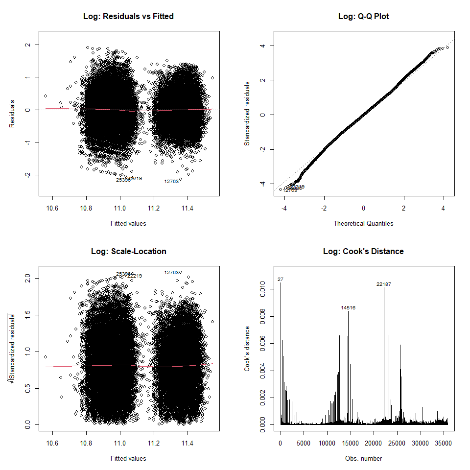

```r
par(mfrow = c(1, 1))
```

```r
par(mar = c(5, 5, 4, 2), mfrow = c(2, 2))

plot(lm_sqrt, which = 1, ann = FALSE, sub.caption = "")
title(main = "Sqrt: Residuals vs Fitted", xlab = "Fitted values", ylab = "Residuals")
```

```r
plot(lm_sqrt, which = 2, ann = FALSE, sub.caption = "")
title(main = "Sqrt: Q-Q Plot", xlab = "Theoretical Quantiles", ylab = "Standardized residuals")
```

```r
plot(lm_sqrt, which = 3, ann = FALSE, sub.caption = "")
title(main = "Sqrt: Scale-Location", xlab = "Fitted values", ylab = "|Standardized residuals|")
```

```r
plot(lm_sqrt, which = 4, ann = FALSE, sub.caption = "")
title(main = "Sqrt: Cook's Distance", xlab = "Obs. number", ylab = "Cook's distance")
```

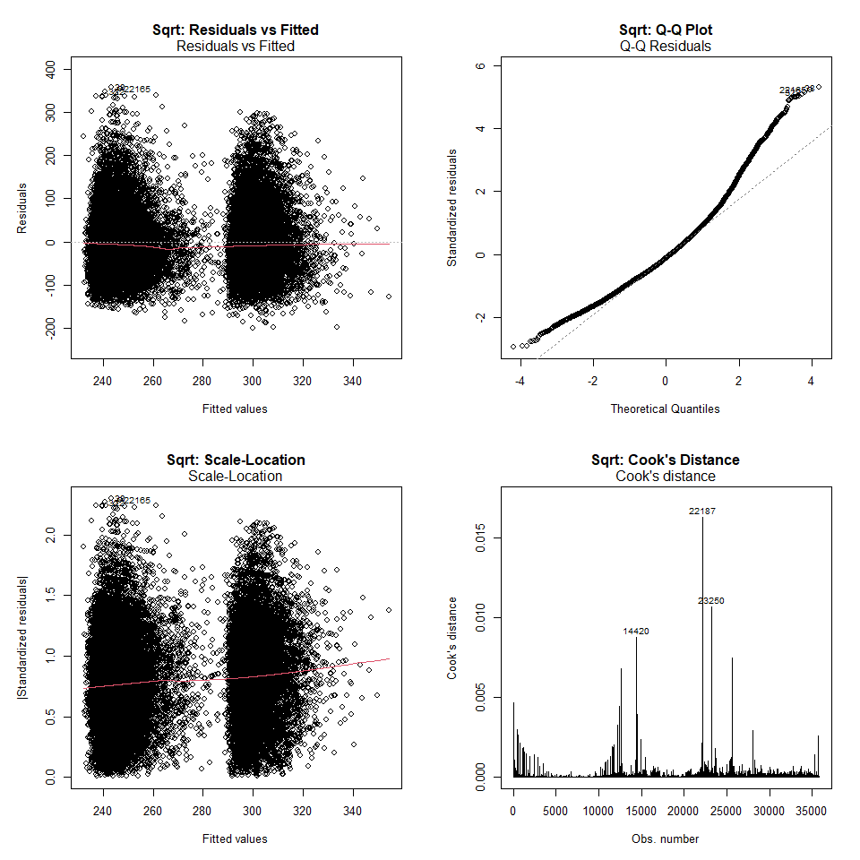

```r
par(mfrow = c(1, 1))
```

```r
# Compare residual distributions
par(mfrow = c(1, 2))

hist(residuals(lm_step), breaks = 50, col = "steelblue", border = "white",
     main = paste("Log Transform Residuals\nSkewness:",
                  round(skewness(residuals(lm_step)), 3)),
     xlab = "Residuals", probability = TRUE)
curve(dnorm(x, mean = mean(residuals(lm_step)), sd = sd(residuals(lm_step))),
      add = TRUE, col = "red", lwd = 2)
```

```r
hist(residuals(lm_sqrt), breaks = 50, col = "#e67e22", border = "white",
     main = paste("Sqrt Transform Residuals\nSkewness:",
                  round(skewness(residuals(lm_sqrt)), 3)),
     xlab = "Residuals", probability = TRUE)
curve(dnorm(x, mean = mean(residuals(lm_sqrt)), sd = sd(residuals(lm_sqrt))),
      add = TRUE, col = "red", lwd = 2)
```

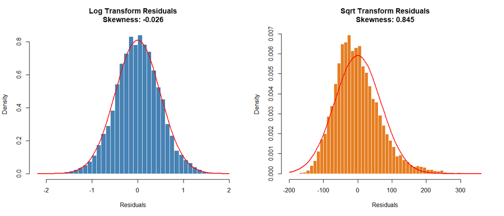

```r
par(mfrow = c(1, 1))
```

- **Row 1 (Residuals vs Fitted):** checks linearity,which transformation produces a flatter, more random scatter?
- **Row 2 (Q-Q Plot):** checks normality,which one follows the diagonal line more closely
- **Row 3 (Scale-Location):** checks homoscedasticity,which one has a more horizontal red line
- **Row 4 (Cook’s Distance):** checks influence — which one has fewer extreme outliers?

**Histogram chunk:** directly compares the residual distributions with skewness values and a normal curve overlay

## Model 2: Decision Tree Regressor

```r
dt_model <- rpart(person_income ~ person_age + person_gender + person_education +
                    person_emp_exp + person_home_ownership + age_exp_ratio +
                    credit_hist_per_age,
                  data = train_reg,
                  method = "anova",
                  control = rpart.control(cp = 0.001, maxdepth = 10, minsplit = 20))

# Print tree summary
printcp(dt_model)
```

[output not shown]

## Model 3: Random Forest Regressor

```r
set.seed(42)
rf_model <- randomForest(person_income ~ person_age + person_gender +
                           person_education + person_emp_exp +
                           person_home_ownership + age_exp_ratio +
                           credit_hist_per_age,
                         data = train_reg,
                         ntree = 500,
                         mtry = 3,
                         importance = TRUE)

print(rf_model)
```

[output not shown]

```r
varImpPlot(rf_model, main = "Random Forest: Variable Importance")
```

[output not shown]

```r
plot(rf_model, main = "Random Forest: Error Convergence")
```

[output not shown]

## Model Comparison: Regression

We compare all three models on the **test set** using standard regression metrics.

```r
# Predictions on test set
# Linear Regression (back-transform from log)
pred_lm   <- exp(predict(lm_step, newdata = test_reg))
# Decision Tree
pred_dt   <- predict(dt_model, newdata = test_reg)
# Random Forest
pred_rf   <- predict(rf_model, newdata = test_reg)

actual <- test_reg$person_income
```

```r
# Calculate metrics for each model
calc_metrics <- function(actual, predicted, model_name) {
  data.frame(
    Model     = model_name,
    RMSE      = round(rmse(actual, predicted), 2),
    MAE       = round(mae(actual, predicted), 2),
    R_Squared = round(1 - sum((actual - predicted)^2) / sum((actual - mean(actual))^2), 4),
    MAPE      = round(mean(abs((actual - predicted) / actual)) * 100, 2)
  )
}

comparison_reg <- rbind(
  calc_metrics(actual, pred_lm, "Linear Regression (log)"),
  calc_metrics(actual, pred_dt, "Decision Tree"),
  calc_metrics(actual, pred_rf, "Random Forest")
)

print(comparison_reg)
```

[output not shown]

```r
comparison_long <- comparison_reg %>%
  pivot_longer(cols = c(RMSE, MAE, R_Squared), names_to = "Metric", values_to = "Value")

ggplot(comparison_long, aes(x = Model, y = Value, fill = Model)) +
  geom_col(alpha = 0.8) +
  facet_wrap(~Metric, scales = "free_y") +
  labs(title = "Regression Model Comparison", y = "Value") +
  theme(axis.text.x = element_text(angle = 30, hjust = 1), legend.position = "none")
```

[output not shown]

### Actual vs Predicted Scatter Plots

```r
pred_df <- data.frame(
  Actual = rep(actual, 3),
  Predicted = c(pred_lm, pred_dt, pred_rf),
  Model = rep(c("Linear Regression", "Decision Tree", "Random Forest"),
              each = length(actual))
)

ggplot(pred_df, aes(x = Actual, y = Predicted)) +
  geom_point(alpha = 0.15, size = 1, color = "steelblue") +
  geom_abline(slope = 1, intercept = 0, color = "red", linetype = "dashed", linewidth = 1) +
  facet_wrap(~Model, ncol = 3) +
  scale_x_continuous(labels = scales::comma, limits = c(0, 300000)) +
  scale_y_continuous(labels = scales::comma, limits = c(0, 300000)) +
  labs(title = "Actual vs Predicted Income",
       subtitle = "Points on the red line = perfect prediction",
       x = "Actual Income (USD)", y = "Predicted Income (USD)") +
  theme(
    plot.title    = element_text(size = 16, face = "bold"),
    plot.subtitle = element_text(size = 12),
    axis.text.x   = element_text(size = 9, angle = 45, hjust = 1),
    axis.text.y   = element_text(size = 9),
    axis.title    = element_text(size = 13),
    strip.text    = element_text(size = 13, face = "bold")
  )
```

[output not shown]

### Final Regression Model Selection

```r
best_model_idx <- which.max(comparison_reg$R_Squared)
cat("BEST REGRESSION MODEL :", "\n")
cat("Model:", comparison_reg$Model[best_model_idx], "\n")
cat("R-squared:", comparison_reg$R_Squared[best_model_idx], "\n")
cat("RMSE:", comparison_reg$RMSE[best_model_idx], "\n")
cat("MAE:", comparison_reg$MAE[best_model_idx], "\n")
```

[output not shown]

# Part B: Classification Loan Default Prediction

## Objective

Predict whether a loan applicant will default (`loan_status = 0`) or repay (`loan_status = 1`) using all available features, including engineered ones

## Prepare Classification Data

```r
clf_df <- df %>%
  dplyr::select(loan_status, person_age, person_gender, person_education, person_income,
                person_emp_exp, person_home_ownership, loan_amnt, loan_intent,
                loan_int_rate, loan_percent_income, cb_person_cred_hist_length,
                credit_score, previous_loan_defaults_on_file,
                loan_credit_ratio, age_exp_ratio, high_risk) %>%
  drop_na()

clf_df$person_education <- factor(clf_df$person_education, ordered = FALSE)

cat("Classification dataset:", nrow(clf_df), "rows x", ncol(clf_df), "columns\n")
```

[output not shown]

## Train-Test Split

```r
set.seed(42)
train_idx_clf <- createDataPartition(clf_df$loan_status, p = 0.8, list = FALSE)
train_clf <- clf_df[train_idx_clf, ]
test_clf  <- clf_df[-train_idx_clf, ]

cat("Training:", nrow(train_clf), "| Test:", nrow(test_clf), "\n")
```

[output not shown]

## Model: Logistic Regression (Classification)

Logistic regression is the standard baseline for binary classification problems and is the natural extension of linear regression for binary outcomes.

```r
log_model <- glm(loan_status ~ ., data = train_clf, family = binomial(link = "logit"))
log_step  <- stepAIC(log_model, direction = "both", trace = FALSE)

prob_log  <- predict(log_step, newdata = test_clf, type = "response")
pred_log  <- factor(ifelse(prob_log > 0.5, 1, 0), levels = c("0", "1"))

cat("\n Logistic Regression \n")
cm_log <- confusionMatrix(pred_log, test_clf$loan_status, positive = "1")
print(cm_log)
```

[output not shown]

## Model: Random Forest Classifier

```r
set.seed(42)
rf_clf <- randomForest(loan_status ~ ., data = train_clf,
                       ntree = 500, mtry = 4, importance = TRUE)

pred_rf_clf <- predict(rf_clf, newdata = test_clf)
prob_rf_clf <- predict(rf_clf, newdata = test_clf, type = "prob")[, 2]

cat("\n Random Forest \n")
cm_rf <- confusionMatrix(pred_rf_clf, test_clf$loan_status, positive = "1")
print(cm_rf)
```

[output not shown]